# Package Test Script

19 July 2019

#### Name: **Paul_Mrosso**

#### Email Address: **pmrosso@ihi.or.tz**

#### R Version: **R version 3.6.1 (2019-07-05)**

### Check packages are loaded:

dplyr: TRUE *version 0.8.3*  
ggplot2: TRUE *version 3.2.0*  
htmltools: TRUE *version 0.3.6*  
rmarkdown: TRUE *version 1.14*  
knitr: TRUE *version 1.23*  
leaflet: TRUE *version 2.0.2*  
lubridate: TRUE *version 1.7.4*  
magrittr: TRUE *version 1.5*  
mapview: TRUE *version 2.7.0*  
pillar: TRUE *version 1.4.2*  
plotly: TRUE *version 4.9.0*  
png: TRUE *version 0.1.7*  
raster: TRUE *version 2.9.23*  
RColorBrewer: TRUE *version 1.1.2*  
rgdal: TRUE *version 1.4.4*  
rgeos: TRUE *version 0.4.3*  
rlang: TRUE *version 0.4.0*  
kableExtra: TRUE *version 1.1.0*  
sf: TRUE *version 0.7.6*  
shiny: TRUE *version 1.3.2*  
shinydashboard: TRUE *version 0.7.1*  
shinyWidgets: TRUE *version 0.4.8*  
tidyverse: TRUE *version 1.2.1*  
vctrs: TRUE *version 0.2.0*  
Xmisc: TRUE *version 0.2.1*

### Additional checks:

**ggplot2** barplot subsetted with **dplyr** from 2000 onwards, coloured red, blue & green by species with **RColorBrewer**.

If If data is shown from 1990 to 2015, **dplyr** is missing.

If bars are plotted in grey, **rColorBrewer** is missing.

Check plot title for ggplot2/base R

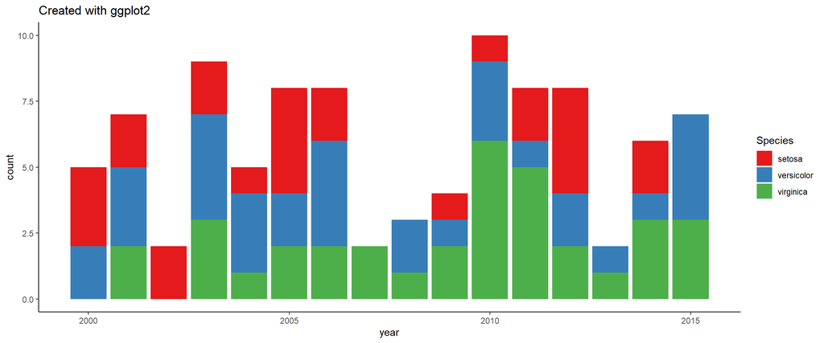

**leaflet** map with points coloured red and labelled with **htmltools**, with Scotland polygon coloured orange, loaded and transformed using **rgdal**.

If data is plotted as a scatter plot, **leaflet** is missing.

If no polygons appear over Scotland, **rgdal** is missing.

[interactive chart not shown]

**kableExtra** formatted table ordered by date column, created using **lubridate**.

If table is not contained in a scroll box, **kableExtra** is missing.

If table is not ordered by date in the format yyyy-mm-dd, **lubridate** is missing.

| date | Species | Sepal.Length | Sepal.Width | Petal.Length | Petal.Width |
| --- | --- | --- | --- | --- | --- |
| 1990-01-11 | versicolor | 6.5 | 2.8 | 4.6 | 1.5 |
| 1990-02-09 | virginica | 6.2 | 3.4 | 5.4 | 2.3 |
| 1990-02-10 | setosa | 5.1 | 3.7 | 1.5 | 0.4 |
| 1990-02-26 | setosa | 5.2 | 3.4 | 1.4 | 0.2 |
| 1990-03-03 | virginica | 6.7 | 3.0 | 5.2 | 2.3 |
| 1990-04-06 | setosa | 5.5 | 4.2 | 1.4 | 0.2 |
| 1990-05-01 | versicolor | 5.4 | 3.0 | 4.5 | 1.5 |
| 1990-11-27 | versicolor | 5.5 | 2.4 | 3.7 | 1.0 |
| 1990-12-08 | versicolor | 6.0 | 2.2 | 4.0 | 1.0 |
| 1991-05-17 | setosa | 5.1 | 3.8 | 1.5 | 0.3 |
| 1991-06-22 | setosa | 5.5 | 3.5 | 1.3 | 0.2 |
| 1991-07-07 | versicolor | 5.7 | 2.8 | 4.1 | 1.3 |
| 1991-11-08 | setosa | 5.0 | 3.5 | 1.3 | 0.3 |
| 1992-03-19 | versicolor | 5.8 | 2.6 | 4.0 | 1.2 |
| 1992-03-26 | versicolor | 5.7 | 2.9 | 4.2 | 1.3 |
| 1992-04-12 | setosa | 4.9 | 3.0 | 1.4 | 0.2 |
| 1992-10-01 | virginica | 6.5 | 3.0 | 5.5 | 1.8 |
| 1992-12-21 | versicolor | 6.0 | 2.9 | 4.5 | 1.5 |
| 1993-02-08 | setosa | 5.0 | 3.6 | 1.4 | 0.2 |
| 1993-05-05 | versicolor | 4.9 | 2.4 | 3.3 | 1.0 |
| 1993-05-17 | setosa | 5.1 | 3.4 | 1.5 | 0.2 |
| 1993-08-20 | virginica | 5.7 | 2.5 | 5.0 | 2.0 |
| 1993-10-10 | setosa | 5.0 | 3.4 | 1.6 | 0.4 |
| 1994-01-23 | virginica | 7.2 | 3.0 | 5.8 | 1.6 |
| 1994-03-20 | versicolor | 5.6 | 2.5 | 3.9 | 1.1 |
| 1994-03-25 | virginica | 5.8 | 2.8 | 5.1 | 2.4 |
| 1994-05-18 | virginica | 6.3 | 2.8 | 5.1 | 1.5 |
| 1994-07-01 | versicolor | 5.8 | 2.7 | 4.1 | 1.0 |
| 1994-07-19 | virginica | 6.8 | 3.0 | 5.5 | 2.1 |
| 1994-09-12 | setosa | 4.3 | 3.0 | 1.1 | 0.1 |

[output cut: 120 more lines]